# Assignment 6: Visualization - Aesthetic Mapping

*How to do it?*:

- Open the Rmarkdown file of this assignment (link) in Rstudio.
- Right under each **question**, insert a code chunk (you can use the hotkey `Ctrl + Alt + I` to add a code chunk) and code the solution for the question.
- `Knit` the rmarkdown file (hotkey: `Ctrl + Alt + K`) to export an html.
- Publish the html file to your Githiub Page.

*Submission*: Submit the link on Github of the assignment to Canvas.

### Questions on Your Selected Data

Choose a dataset and produce the following types of plots and comment on each plot. Plots should be meaningful. If you use the data we used in class, make sure the plots are not the same as the ones in the slides.

```r
# Load data
library(tidyverse)
library(dplyr)
library(ggplot2)

df <- read_csv('global_youtube_statistics.csv')
```

1. For one continuous variable:
- Density

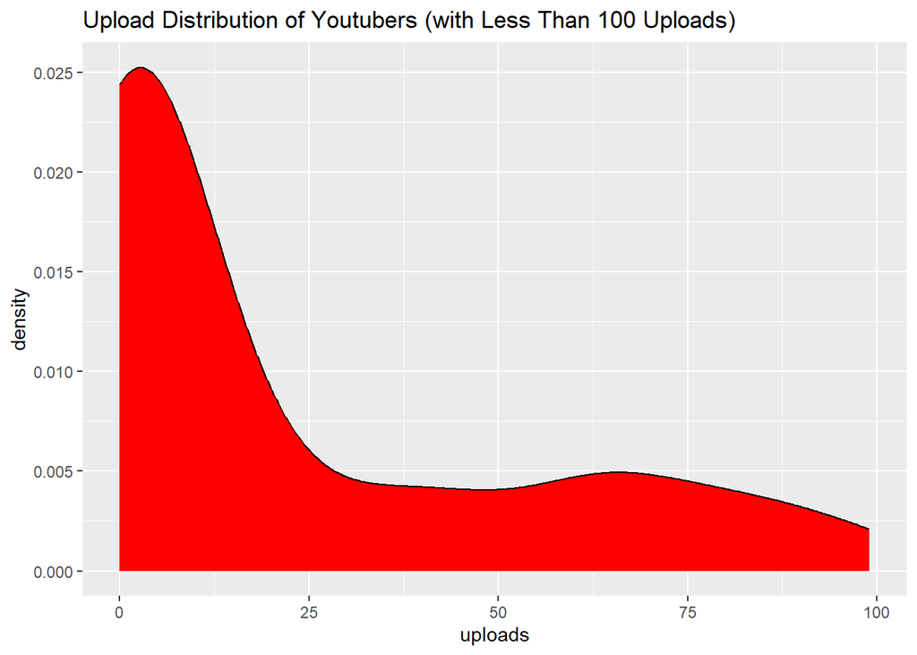

```r
# Filtering df for channels with less than 100 uploads
filtered_df <- df %>% filter(uploads<100)

ggplot(filtered_df, aes(x=uploads)) + geom_density(fill='Red') + ggtitle("Upload Distribution of Youtubers (with Less Than 100 Uploads)")
```

```r
# The above density plot shows the distribution of Youtubers based on the number of times they have uploaded to their channel (limited to those who uploaded 100 or less videos to make the visualization easier to interpret)

# It is clear that in the data set, many of the Youtubers have only uploaded a few videos to their channel (a lot more than the number of Youtubers who have uploaded close to 100)
```

- Histogram

```r
# I decided that I want to create a histogram that visualizes the frequency at which Youtubers created their channels over the years. However, to do this, I need to handle one observation that claimed that a Youtuber created their channel in 1970 (Youtube was founded in 2005).
min(df$created_year, na.rm=TRUE)
```

```
## [1] 1970
```

```r
# I decided to look into this observation to see why its creating date was bizarre
df %>% filter(created_year == 1970)
```

```
## # A tibble: 1 × 28
##    rank Youtuber subscribers `video views` category        Title uploads Country
##   <dbl> <chr>          <dbl>         <dbl> <chr>           <chr>   <dbl> <chr>
## 1   102 YouTube     36300000    3010784935 News & Politics YouT…     744 United…
## # ℹ 20 more variables: Abbreviation <chr>, channel_type <chr>,
## #   video_views_rank <dbl>, country_rank <dbl>, channel_type_rank <dbl>,
## #   video_views_for_the_last_30_days <dbl>, lowest_monthly_earnings <dbl>,
## #   highest_monthly_earnings <dbl>, lowest_yearly_earnings <dbl>,
## #   highest_yearly_earnings <dbl>, subscribers_for_last_30_days <dbl>,
## #   created_year <dbl>, created_month <chr>, created_date <dbl>,
## #   `Gross tertiary education enrollment (%)` <dbl>, Population <dbl>, …
```

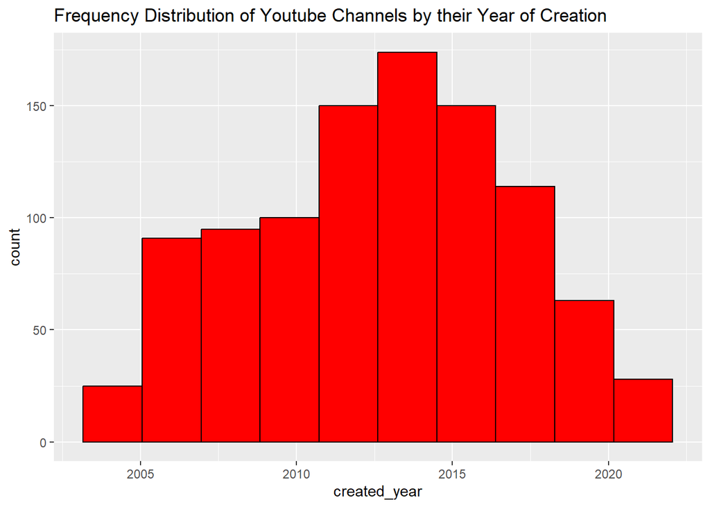

```r
# Apparently this is Youtube's own Youtube channel. I would assume that this channel was created in 2005 however I went onto the site to double check. Although their channel does not have a founded date listed, the first video on the channel was from 2005 and thus, I have decided to impute 2005 to correct this observation.
df$created_year <- replace(df$created_year, df$created_year == 1970, 2005)

ggplot(df, aes(x=created_year)) + geom_histogram(bins=10, na.rm=TRUE, color='Black',fill='Red') + ggtitle("Frequency Distribution of Youtube Channels by their Year of Creation")
```

```r
# It appears that the majority of Youtube channels were created during the early 2010s and that the number of channels created has dropped off over the past half decade. This could potentially indicate a saturation in the Youtube market, as fewer people seem to want to create channels (they could be thinking that they are less likely to get views because many other Youtube channels already have the content that they want to make)
```

- Boxplot

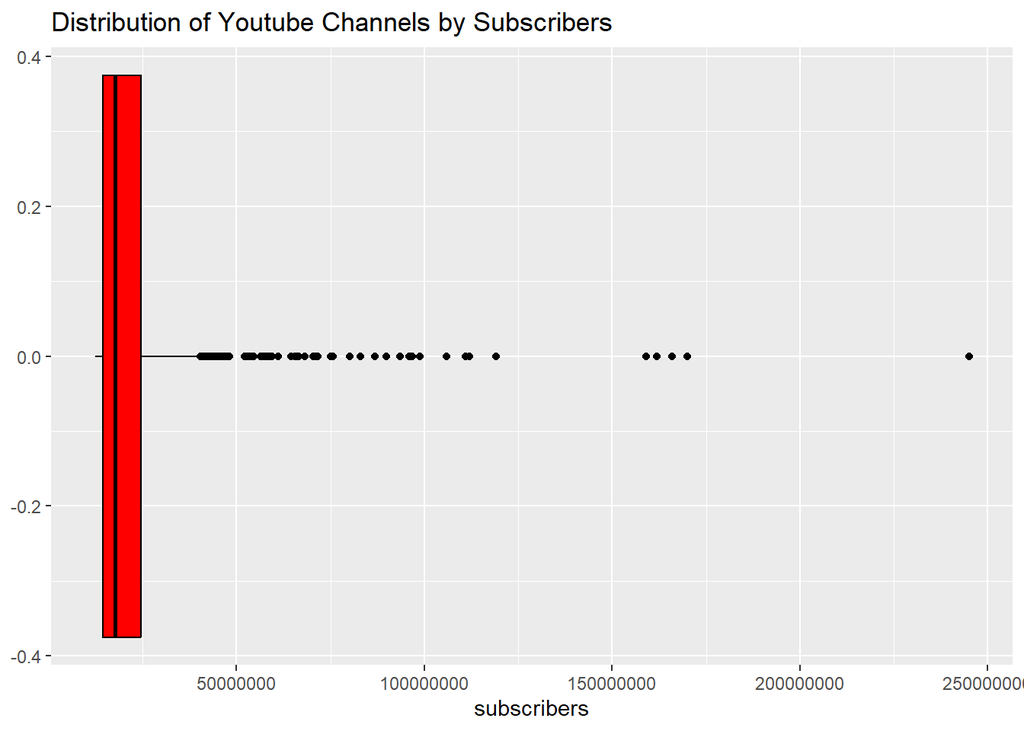

```r
# Making sure that values are not displayed in scientific notation
options(scipen=999)

# Creating boxplot to display distribution of the Youtube Channels in the data set based on the number of subscribers subscribed to the Youtube channel
ggplot(df, aes(x=subscribers)) + geom_boxplot(fill='Red', color='Black') + ggtitle("Distribution of Youtube Channels by Subscribers")
```

```r
# Showing the quartile values displayed on the boxplot
quantile(df$subscribers)
```

```
##        0%       25%       50%       75%      100%
##  12300000  14500000  17700000  24600000 245000000
```

```r
# The distribution is very skewed to the right, with many outliers that are much higher than the rest of the data. This is understandable given that the majority of the channels in the data set only have tens of millions of subscribers (very close to the minimum in the data with 12.3 million), while the outliers go as far up at 245 million subscribers.
```

2. For one categorical variable
- Barplot

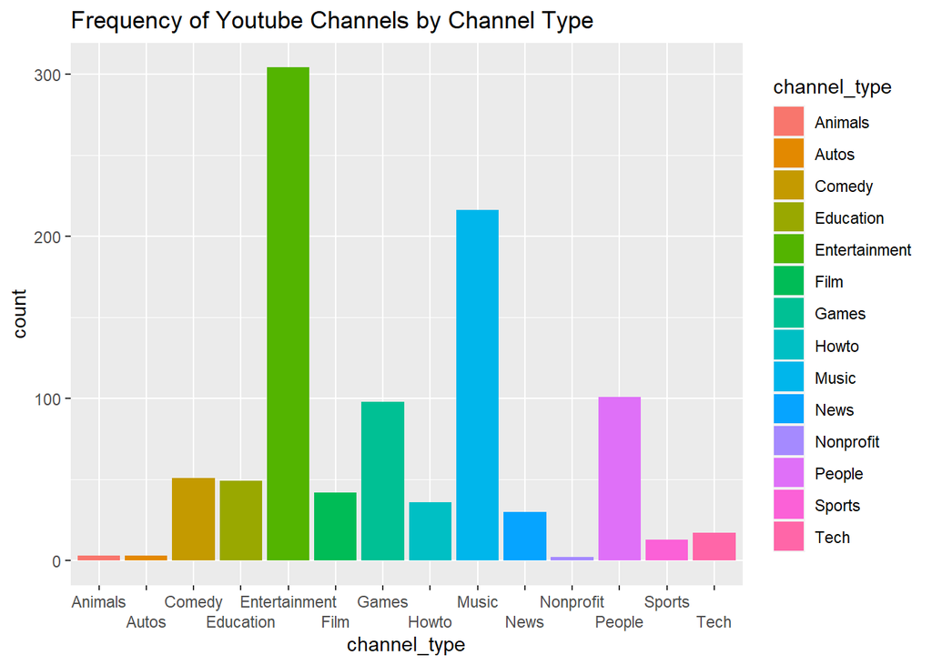

```r
# Converting channel_type value 'nan' to NA
df$channel_type <- na_if(df$channel_type, 'nan')

# Visualizing the number of Youtube channels in the data based on their channel type (being sure to exclude NAs so that these do not appear as a column)
ggplot(data=subset(df, !is.na(channel_type)), aes(x=channel_type, fill=channel_type)) + geom_bar() +
# Had to use 2 rows to display x-axis labels due to overlap
  scale_x_discrete(guide = guide_axis(n.dodge = 2)) + ggtitle("Frequency of Youtube Channels by Channel Type")
```

```r
# It appears that entertainment and music channels are by for the most frequent in the data, however I would like a clearer definition for an 'Entertainment' channel (this feels like a general catch-all category & I was unable to locate a definition for it on the Kaggle page for this dataset).
```

3. For two continuous variables
- Scatter Plot

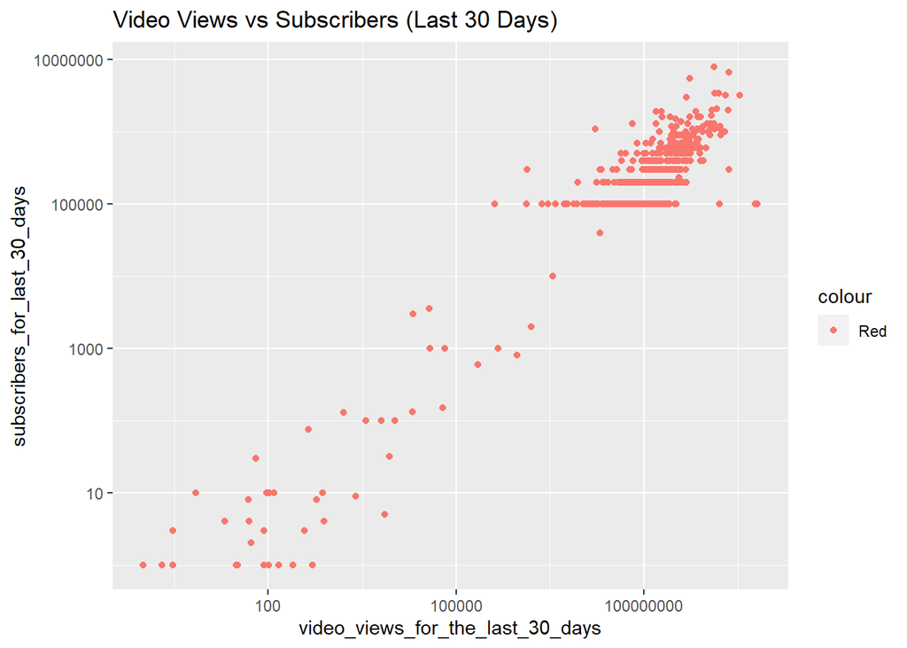

```r
# Filtering out 'NaN' values from columns being used for scatter plot
filtered_df_2 <- df %>% filter(video_views_for_the_last_30_days != 'NaN', subscribers_for_last_30_days != 'NaN')

# Plotting Youtube channels based on their video views and subscribers in the last 30 days
ggplot(filtered_df_2, aes(x=video_views_for_the_last_30_days, y=subscribers_for_last_30_days, color='Red')) + geom_point() + ggtitle("Video Views vs Subscribers (Last 30 Days)") +
# Decided to take log scale of both axes to better visualize the relationship
  scale_x_log10() + scale_y_log10()
```